# CITS4009-project2

### 4.5.2 Descision Tree Classifier

Interpret decision tree model:

Considering the wide readership, we will explain how the decision tree classifier works. A decision tree classifier is an intelligent algorithm that is like a map of answers to a question. It uses a series of questions to determine which category something belongs to. Imagine a tree where the root is the first question and each leaf node represents an answer and the path is determined by answering the question. For example, if we want to differentiate between fruits, the first question might be “Is this fruit round?” If so, go down one branch and ask the next question, and if not, go down another branch. Through a series of questions and answers, the type of fruit was finally determined. This tree structure is very intuitive, making decision tree classifiers easy to understand and use, and suitable for various applications such as disease diagnosis, customer classification, etc.

#### 4.5.2.1 Build Descision Tree Model for all features

First build a model based on all features and observe the performance of the model.

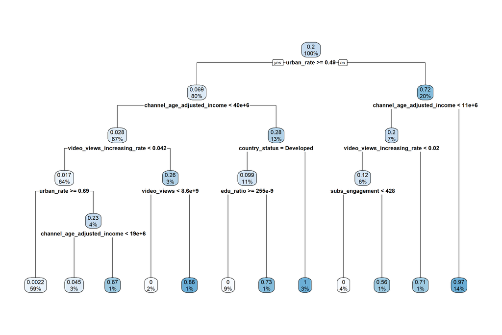

```r
formula_Var1 <- paste(target_column,'> 0 ~ ',paste(c(categorical_independent_variables,numeric_independent_variables), collapse=' + '), sep='')
tmodel1 <- rpart(formula_Var1, data=youtube_train)

# visualization decision tree
rpart.plot(tmodel1)
```

Check the Model Performance

```r
# train set AUC score
tmodel1_train_auc <- AUC_calculator(predict(tmodel1, newdata=youtube_train), youtube_train[,target_column])
cat('tmodel1\'s AUC score on the training set is',tmodel1_train_auc, "\n")
```

```
## tmodel1's AUC score on the training set is 0.9926744
```

```r
# test set AUC score
tmodel1_test_auc <- AUC_calculator(predict(tmodel1, newdata=youtube_test), youtube_test[,target_column])
cat('tmodel1\'s AUC score on the testing set is',tmodel1_test_auc)
```

```
## tmodel1's AUC score on the testing set is 0.9734163
```

```r
# performance table
pretty_perf_table(tmodel1,youtube_train[c(categorical_independent_variables,numeric_independent_variables)],youtube_train[,target_column] == positive_label,youtube_test[c(categorical_independent_variables,numeric_independent_variables)],youtube_test[,target_column] == positive_label)
```

```
##
##
## model                  precision   recall       f1   dev.norm
## -------------------- ----------- -------- -------- ----------
## tmodel1 , training        0.9036   0.9868   0.9434     1.1056
## tmodel1 , testing         0.8684   0.9706   0.9167     0.9334
```

```r
# log likelihood
cat("tmodel1 Log Likelihood:", calculateLogLikelihood(tmodel1, youtube_test, positive_label, epsilon = 1e-6), "\n")
```

```
## tmodel1 Log Likelihood: -0.02955777
```

```r
cat("NULL model Log Likelihood:",logNull)
```

```
## NULL model Log Likelihood: -380.3058
```

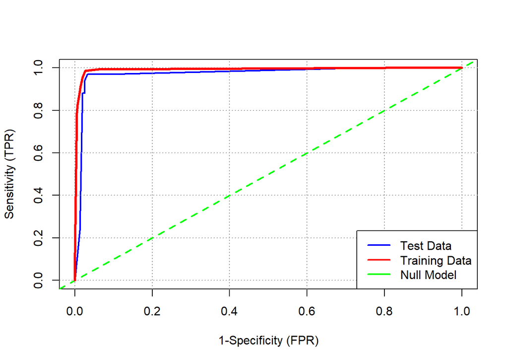

```r
#Print the ROC plot
pred_test_roc_tmodel1 <- predict(tmodel1, newdata=youtube_test)
pred_train_roc_tmodel1 <- predict(tmodel1, newdata=youtube_train)
plot_roc2(pred_test_roc_tmodel1, youtube_test[[target_column]],
         pred_train_roc_tmodel1, youtube_train[[target_column]])
```

The ‘Decision Tree with all features’ model assigns a log likelihood of -0.02955777 which is better than the Null model’s -380.3058. Although the model performs well in terms of AUC and Recall, the Precision is relatively low, indicating that there is a certain number of false positives in cases where the model predicts a positive class. This may cause the model to generate more false positives in practical applications, reducing its reliability and operability. Moreover, the AUC value is too large, and there is a risk of overfitting.